# QA NLI Fine-Tuned Model Report

QA check for a locally fine-tuned NLI classifier (scripts/training/train_nli.py)

Published

September 1, 2026

# nli_config: bge_m3_zeroshot_atomic_bm

## Methodology

This report is a **QA check on a locally fine-tuned NLI classifier (`scripts/training/train_nli.py`), not a scoring result in its own right** — it lets a training run’s real composition, class balance, and held-out performance be spot-checked before deciding whether the resulting model is worth deploying. See `TD_NLI_training.qmd` for the full training-data strategy and fine-tuning design this implements.

Only produced when the active nli config has `train: true` set in `input/config.yaml` — otherwise `nli_finetuned_model` writes an empty marker and this report shows the empty state below rather than a real result.

```r
if (isTRUE(x$empty)) {
  cat(sprintf(
    "No fine-tuned model for `nli_config: %s` — either `train: false` in input/config.yaml (the default), or a run that failed before completing. Set `train: true` for this config and re-run `tar_make(names = \"nli_finetuned_model\")` to produce one.\n\n",
    params$nli_config
  ))
  knitr::knit_exit()
}
```

```r
cat(sprintf("- **Run**: `%s` (%s)\n", x$run_id, x$timestamp))
```

- **Run**: `date=2026.09.01_11_30` (2026-09-01T12:11:51.772964)

```r
cat(sprintf("- **Base model**: `%s`\n", x$model_id))
```

- **Base model**: `MoritzLaurer/bge-m3-zeroshot-v2.0-c`

```r
cat(sprintf("- **Premise mode**: `%s`\n", x$premise_mode))
```

- **Premise mode**: `full`

```r
cat(sprintf(
  "- **Assessments**: %s — **Granularity**: %s\n",
  paste(x$assessments, collapse = ", "), paste(x$granularity, collapse = ", ")
))
```

- **Assessments**: GA1, IAS — **Granularity**: atomic_bm

```r
cat(sprintf(
  "- **%d** total rows (**%d** train / **%d** held-out eval)\n",
  x$n_rows_total, x$n_rows_train, x$n_rows_eval
))
```

- **543** total rows (**461** train / **82** held-out eval)

```r
cat("- Class balance:\n")
```

- Class balance:

```r
for (lab in names(x$label_counts)) {
  cat(sprintf("  - `%s`: %d\n", lab, x$label_counts[[lab]]))
}
```

- `NOT_ENOUGH_INFO`: 181
- `REFUTES`: 181
- `SUPPORTS`: 181

```r
cat("- Key paper vs. citing-work premise:\n")
```

- Key paper vs. citing-work premise:

```r
for (kp in names(x$keypaper_counts)) {
  cat(sprintf("  - `keypaper=%s`: %d\n", kp, x$keypaper_counts[[kp]]))
}
```

- `keypaper=True`: 412
- `keypaper=False`: 131

```r
cat(sprintf(
  "- **Held-out accuracy: %.1f%%** (best checkpoint: `%s`, eval_loss = %.4f)\n",
  100 * x$accuracy, basename(x$best_model_checkpoint), x$best_metric
))
```

- **Held-out accuracy: 70.7%** (best checkpoint: `checkpoint-87`, eval_loss = 0.6087)

## Held-out classification report

Computed on the 82 rows this run never trained on. `support` is the number of true examples of that class in the held-out split — with this few rows, treat individual precision/recall values as indicative, not precise.

```r
DT::datatable(
  x$classification_df, rownames = FALSE, options = list(dom = "t", paging = FALSE)
)
```

| class | precision | recall | f1_score | support |
| --- | --- | --- | --- | --- |
| SUPPORTS | 0.519 | 0.636 | 0.571 | 22 |
| REFUTES | 0.852 | 0.767 | 0.807 | 30 |
| NOT_ENOUGH_INFO | 0.75 | 0.7 | 0.724 | 30 |
| macro avg | 0.707 | 0.701 | 0.701 | 82 |
| weighted avg | 0.725 | 0.707 | 0.713 | 82 |

## Training curve

Eval loss at the end of each epoch — should trend down across epochs if the model is genuinely learning (a flat line at `log(3) ≈ 1.099` — the loss of a classifier guessing uniformly across 3 classes — is the signature of a training run that never actually moved away from its random head initialization).

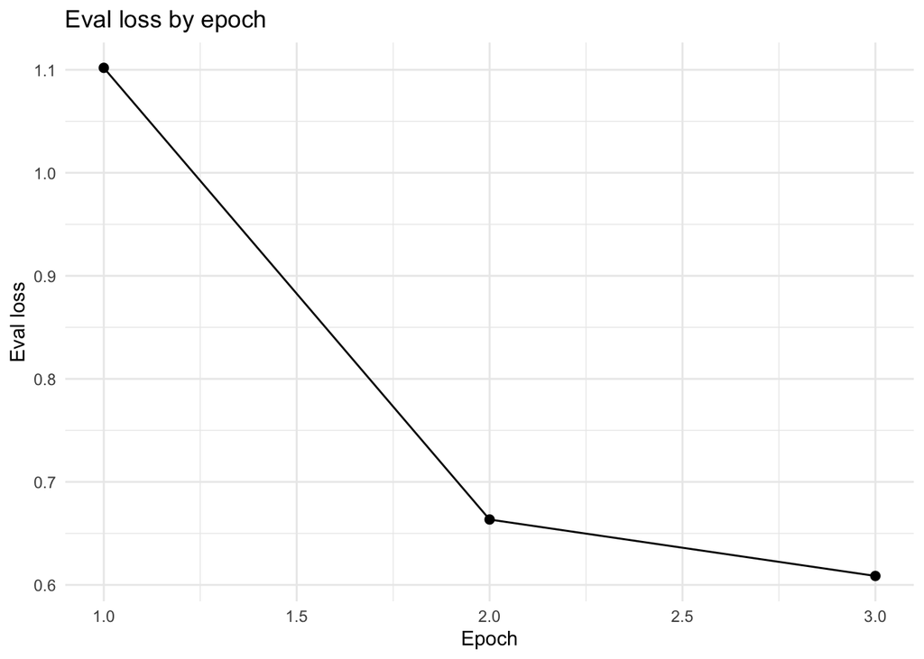

```r
if (!is.null(x$loss_plot)) {
  x$loss_plot
} else {
  cat("No eval_loss entries in the training log.")
}
```

Full per-step log (loss, grad_norm, learning_rate where logged; eval_loss at each epoch boundary):

```r
DT::datatable(
  x$log_df, rownames = FALSE,
  options = list(dom = "t", paging = FALSE, scrollX = TRUE)
)
```

| epoch | step | loss | grad_norm | learning_rate | eval_loss |
| --- | --- | --- | --- | --- | --- |
| 0.6896551724137931 | 20 | 1.0064 | 9.587188720703125 | 3.908045977011495e-05 |  |
| 1 | 29 |  |  |  | 1.101885199546814 |
| 1.379310344827586 | 40 | 0.8627 | 9.667686462402344 | 2.758620689655173e-05 |  |
| 2 | 58 |  |  |  | 0.6634981036186218 |
| 2.068965517241379 | 60 | 0.8301 | 18.54424285888672 | 1.609195402298851e-05 |  |
| 2.758620689655173 | 80 | 0.6097 | 21.0489559173584 | 4.597701149425287e-06 |  |
| 3 | 87 |  |  |  | 0.6086996793746948 |
| 3 | 87 |  |  |  |  |